# Project Foundations for Data Science: FoodHub Data Analysis

**Marks: 40 points**

### Context

The number of restaurants in New York is increasing day by day. Lots of students and busy professionals rely on those restaurants due to their hectic lifestyles. Online food delivery service is a great option for them. It provides them with good food from their favorite restaurants. A food aggregator company FoodHub offers access to multiple restaurants through a single smartphone app.

The app allows the restaurants to receive a direct online order from a customer. The app assigns a delivery person from the company to pick up the order after it is confirmed by the restaurant. The delivery person then uses the map to reach the restaurant and waits for the food package. Once the food package is handed over to the delivery person, he/she confirms the pick-up in the app and travels to the customer's location to deliver the food. The delivery person confirms the drop-off in the app after delivering the food package to the customer. The customer can rate the order in the app. The food aggregator earns money by collecting a fixed margin of the delivery order from the restaurants.

### Objective

The food aggregator company has stored the data of the different orders made by the registered customers in their online portal. They want to analyze the data to get a fair idea about the demand of different restaurants which will help them in enhancing their customer experience. Suppose you are a Data Scientist at Foodhub and the Data Science team has shared some of the key questions that need to be answered. Perform the data analysis to find answers to these questions that will help the company to improve the business.

### Data Description

The data contains the different data related to a food order. The detailed data dictionary is given below.

### Data Dictionary

- order_id: Unique ID of the order
- customer_id: ID of the customer who ordered the food
- restaurant_name: Name of the restaurant
- cuisine_type: Cuisine ordered by the customer
- cost_of_the_order: Cost of the order
- day_of_the_week: Indicates whether the order is placed on a weekday or weekend (The weekday is from Monday to Friday and the weekend is Saturday and Sunday)
- rating: Rating given by the customer out of 5
- food_preparation_time: Time (in minutes) taken by the restaurant to prepare the food. This is calculated by taking the difference between the timestamps of the restaurant's order confirmation and the delivery person's pick-up confirmation.
- delivery_time: Time (in minutes) taken by the delivery person to deliver the food package. This is calculated by taking the difference between the timestamps of the delivery person's pick-up confirmation and drop-off information

### Import the Required Libraries

```python
# Import the libraries needed for the project
import numpy as np
import pandas as pd

import matplotlib.pyplot as plt
import seaborn as sns
```

Explain the Libraries: The libraries used for this analysis are Numpy, Pandas, Seaborn, and Matplotlib.

- Numpy for numerical analysis and for computing arrays
- Pandas for processing, cleaning, and analysing the data
- Seaborn for some additional statistical visualization models
- Matplotlib for visualization

### Understanding the structure of the data

### **Question 1:** How many rows and columns are present in the data?

```python
# Next step is to import the data that was provided for the analysis
df = pd.read_csv('foodhub_order.csv')
```

Explain the code:

The Pandas pd.read_csv code is used to import the file into the Jupyter notebook

```python
# This will show the first 5 rows of the data set and all of the columns.
df.head()
```

|  | order_id | customer_id | restaurant_name | cuisine_type | cost_of_the_order | day_of_the_week | rating | food_preparation_time | delivery_time |
| --- | --- | --- | --- | --- | --- | --- | --- | --- | --- |
| 0 | 1477147 | 337525 | Hangawi | Korean | 30.75 | Weekend | Not given | 25 | 20 |
| 1 | 1477685 | 358141 | Blue Ribbon Sushi Izakaya | Japanese | 12.08 | Weekend | Not given | 25 | 23 |
| 2 | 1477070 | 66393 | Cafe Habana | Mexican | 12.23 | Weekday | 5 | 23 | 28 |
| 3 | 1477334 | 106968 | Blue Ribbon Fried Chicken | American | 29.20 | Weekend | 3 | 25 | 15 |
| 4 | 1478249 | 76942 | Dirty Bird to Go | American | 11.59 | Weekday | 4 | 25 | 24 |

```python
# Find the total rows and columns in the dataset
df.shape
```

```
(1898, 9)
```

Answer: There is a total of 1,898 rows and 9 columns of data in this dataset. The df.shape code will display the overall shape or dimensions (rows and columns) of the dataset.

Note: The reason why head() and tail() require the '()' is because these are considered functions. This is required for Python to recognize that a function is being used. The code .shape is an attribute of the dataframe and returns a tuple

### **Question 2:** What are the datatypes of the different columns in the dataset?

```python
df.info()
```

```
<class 'pandas.core.frame.DataFrame'>
RangeIndex: 1898 entries, 0 to 1897
Data columns (total 9 columns):
 #   Column                 Non-Null Count  Dtype
---  ------                 --------------  -----
 0   order_id               1898 non-null   int64
 1   customer_id            1898 non-null   int64
 2   restaurant_name        1898 non-null   object
 3   cuisine_type           1898 non-null   object
 4   cost_of_the_order      1898 non-null   float64
 5   day_of_the_week        1898 non-null   object
 6   rating                 1898 non-null   object
 7   food_preparation_time  1898 non-null   int64
 8   delivery_time          1898 non-null   int64
dtypes: float64(1), int64(4), object(4)
memory usage: 133.6+ KB
```

The .info code will summarize the information about the variables that are within the dataset. The summary shows the position of the variable in the dataset (column number), name of the variable, how many non-null values there are for each variable, and the datatype of each variable.

This dataset contains 9 variables that are either integers(numerical) or objects (categorical), or floating (decimal) values

- Numerical values are: order_id, customer_id, food_preparation_time, delivery_time
- Categorical values are: restaurant_name, cuisine_type, day_of_the_week, rating
- Floating value is: cost_of_the_order

The summary also displays the amount of memory used for this dataset.

### **Question 3:** Are there any missing values in the data? If yes, treat them using an appropriate method.

```python
# Check for missing values
df.isnull().values.any()
```

```
False
```

Explain the code:

df.isnull().values.any()

- df is the name of the dataframe
- isnull() is asking Python to check for values that are null
- .values means that Python will check across all columns and not a specific column to find any null values
- Since there are no null values found, the result of the query is FALSE

There are no blanks or missing data in this dataset. This means that all of the data/records are present and available for analyis.

### **Question 4:** Check the statistical summary of the data. What is the minimum, average, and maximum time it takes for food to be prepared once an order is placed?

```python
# Get the summary statistics of the numerical data
df.describe()
```

|  | order_id | customer_id | cost_of_the_order | food_preparation_time | delivery_time |
| --- | --- | --- | --- | --- | --- |
| count | 1.898000e+03 | 1898.000000 | 1898.000000 | 1898.000000 | 1898.000000 |
| mean | 1.477496e+06 | 171168.478398 | 16.498851 | 27.371970 | 24.161749 |
| std | 5.480497e+02 | 113698.139743 | 7.483812 | 4.632481 | 4.972637 |
| min | 1.476547e+06 | 1311.000000 | 4.470000 | 20.000000 | 15.000000 |
| 25% | 1.477021e+06 | 77787.750000 | 12.080000 | 23.000000 | 20.000000 |
| 50% | 1.477496e+06 | 128600.000000 | 14.140000 | 27.000000 | 25.000000 |
| 75% | 1.477970e+06 | 270525.000000 | 22.297500 | 31.000000 | 28.000000 |
| max | 1.478444e+06 | 405334.000000 | 35.410000 | 35.000000 | 33.000000 |

Explain:

The .describe code will display the summary statistics of all the numerical values in the dataset. This summary includes count, mean, std, min, max, and the percentiles/quadrants. This summary is used to get a general idea of the data for further analysis.

### **Question 5:** How many orders are not rated?

```python
# Use .value_counts
df['rating'].value_counts()
```

```
Not given    736
5            588
4            386
3            188
Name: rating, dtype: int64
```

Explain the code:

df['rating'].value_counts()

- df is the name of the dataframe
- df.['rating'] is asking Python to evaluate the 'rating' column within the df dataframe
- .value_counts() is asking Python to return the count of all the values within the column 'rating' in the df dataframe

Results: There are a total of 736 rows in the 'rating' column that have a value of Not given. This means that there are 736 orders within this dataset that did not receive a rating from the customer

### Exploratory Data Analysis (EDA)

### **Question 6:** Explore all the variables and provide observations on their distributions. (Generally, histograms, boxplots, countplots, etc. are used for univariate exploration)

#### Order ID

```python
# Check to see how many unqiue order_id values there are in the dataset
df['order_id'].nunique()
```

```
1898
```

Since the number of unquie_id values is equal to the total number of rows in the dataset, it can be concluded that all of the order_id values are unique. In other words, there are no duplicate order_id values in the dataset.

#### Customer ID

```python
# Check to see how many unqiue customer_id values there are in the dataset
df['customer_id'].nunique()
```

```
1200
```

The number of unique customer_id values is 1200. Since the total number of rows in the data set is 1898, this means that there are duplicate customer_id values in the dataset. These values would represent repeate business by a customer.

#### Restaurant name

```python
# Check to see how many unqiue restaurant_name values there are in the dataset
df['restaurant_name'].nunique()
```

```
178
```

There are a total of 178 different restaurant names within the dataset. This represents the different restaurants that customers are ordering from using the FoodHub app.

#### Cuisine type

```python
# Check to see how many unqiue cuisine_type values there are in the dataset
df['cuisine_type'].nunique()
```

```
14
```

There are a total of 14 different cuisine types within the dataset. This represents the different types of cuisine that customers are ordering using the FoodHub app

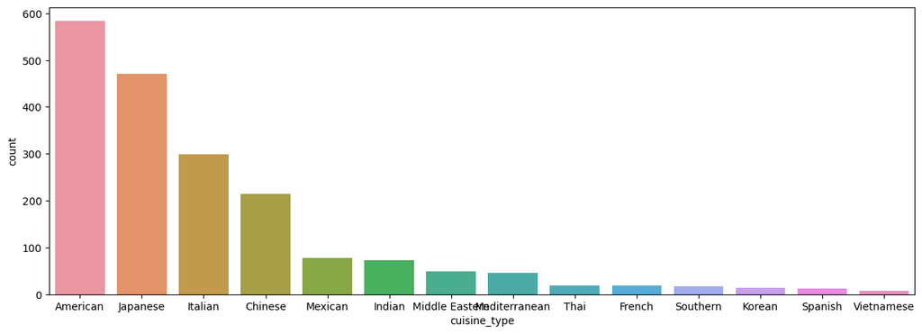

```python
# Visualizing the different cuisine types
plt.figure(figsize = (15,5))
#sns.countplot(data = df, x = 'cuisine_type')
sns.countplot(data = df, x = 'cuisine_type', order=df['cuisine_type'].value_counts(ascending=False).index)
```

Explain the plot:

plt.figure(figsize = (15,5)) sns.countplot(data = df, x = 'cuisine_type')

- the plt calls in the library matplotlib.pyplot that was imported at the start of the project. This library provides the structure to Python for plotting
- the figure size controls the size of the image that is displayed
- sns. calls in the library seaborn.sns for the countplot. Seaborn library provides Python the structure to visualize the results into the plot that is selected (countplot in this case)
- the variables used for this plot is the data taken from the 'cuisine_type' column within the df dataframe

Results of the countplot:

The countplot shows the counts or values of each of the different cuisine types that are found in the data set. The top three appear to be American, Japanese, and Italian.

#### Cost of the order

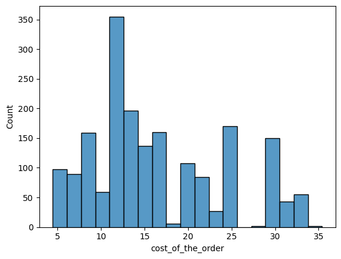

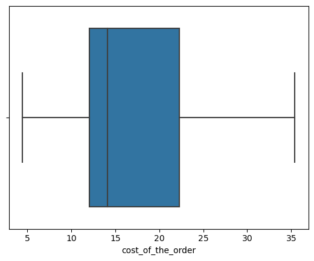

```python
# Create histogram and boxplot
sns.histplot(data=df,x='cost_of_the_order')
plt.show()
sns.boxplot(data=df,x='cost_of_the_order')
plt.show()
```

Explain the code:

These plots use the same libraries as the previous one (matplotlib.pyplot and seaborn). The code is telling Python to use the data contained in the 'cost_of_the_order' column within the df dataframe to create a histogram and boxplot of the values.

Results of the plots: The data also shows that the results are skewed right which is supported by the median value being $14.14

The results show a binomial distribution which indicates that the variation is not normalized with a standard deviation of $7.48.

#### Day of the week

```python
# Check to see how many unqiue day_of_the_week values there are in the dataset
df['day_of_the_week'].nunique()
```

```
2
```

The results show that there are 2 unique values for the day of the week column.

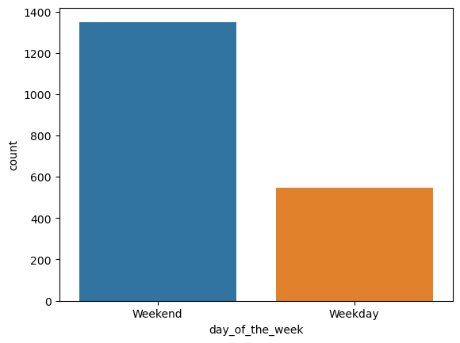

```python
# Graph the values within the day_of_the_week column
sns.countplot(data = df, x = 'day_of_the_week')
```

The values that are in the day_of_the_week column fit into 2 unique categories; Weekend or Weekday. The results show that majority of the orders are placed on the Weekend vs. Weekday

#### Rating

```python
# Check to see how many unqiue 'rating' values there are in the dataset
df['rating'].nunique()
```

```
4
```

There are 4 different unique values within the 'rating' column of the dataset

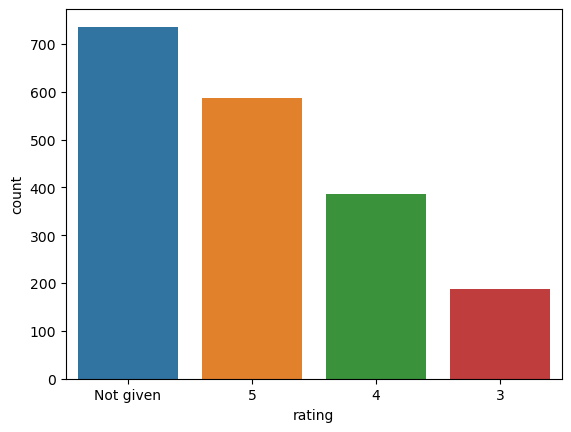

```python
sns.countplot(data = df, x = 'rating', order=df['rating'].value_counts(ascending=False).index) ## Complete the code to plot bar graph for 'rating' column
```

The countplot uses seaborn to visualize the 4 different unique values within the 'rating' column of the dataset. Majority of the orders were not given a rating by the customer. Of the orders that were given a rating, a rating of 5 appears to be the most prevelent.

#### Food Preparation time

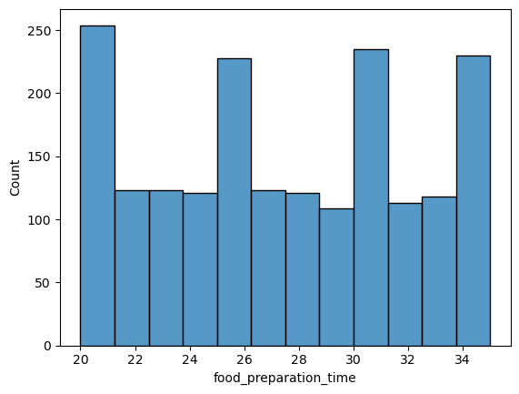

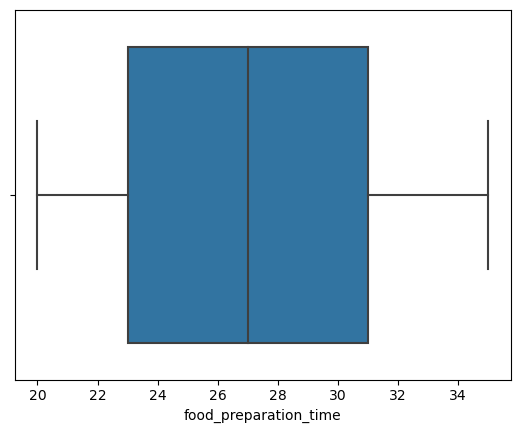

```python
sns.histplot(data=df,x='food_preparation_time')
plt.show()
sns.boxplot(data=df,x='food_preparation_time')
```

Results of the plots:

- The histogram shows data is not normalized
- The boxplot shows the median value of about 27 which was also determined in the summary statistics above.
- The boxplot does not show any outliers; also has the Q1 and Q3 quartiles as well as the min and max

#### Delivery time

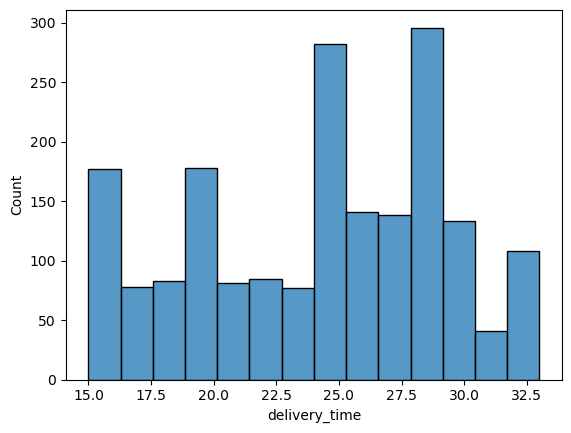

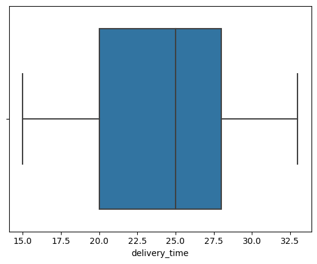

```python
sns.histplot(data=df,x='delivery_time')
plt.show()
sns.boxplot(data=df,x='delivery_time')
plt.show()
```

The binomial distribution shows that the delivery time is not normalized and contains variation both above and below the mean time of deliver (24.16 minutes). This is supported by a standard deviation of 4.97 minutes. Variation is also present on the box plot where the median value of 25.

### **Question 7:** Which are the top 5 restaurants in terms of the number of orders received?

```python
# Top 5 restaurants with the highest number of orders
df['restaurant_name'].value_counts()
```

```
Shake Shack                  219
The Meatball Shop            132
Blue Ribbon Sushi            119
Blue Ribbon Fried Chicken     96
Parm                          68
                            ...
Sushi Choshi                   1
Dos Caminos Soho               1
La Follia                      1
Philippe Chow                  1
'wichcraft                     1
Name: restaurant_name, Length: 178, dtype: int64
```

The top 5 restaurants with the most orders are:

Shake Shack

- The Meatball Shop
- Blue Ribbon Sushi
- Blue Ribbon Fried Chicken
- Parm

### **Question 8:** Which is the most popular cuisine on weekends?

```python
# What cuisine is most popular on the weekends?
df_weekend = df[df['day_of_the_week'] == 'Weekend']
df_weekend['cuisine_type'].value_counts()
```

```
American          415
Japanese          335
Italian           207
Chinese           163
Mexican            53
Indian             49
Mediterranean      32
Middle Eastern     32
Thai               15
French             13
Korean             11
Southern           11
Spanish            11
Vietnamese          4
Name: cuisine_type, dtype: int64
```

The most popular cuisine on the weekend is American

### **Question 9:** What percentage of the orders cost more than 20 dollars?

```python
# Get orders that cost above 20 dollars
df_greater_than_20 = df[df['cost_of_the_order']>20]

# How many orders cost more than $20
print('The number of total orders that cost above 20 dollars is:', df_greater_than_20.shape[0])

# What is the total % of these orders
percentage = (df_greater_than_20.shape[0] / df.shape[0]) * 100

print("Percentage of orders above 20 dollars:", round(percentage, 2), '%')
```

```
The number of total orders that cost above 20 dollars is: 555
Percentage of orders above 20 dollars: 29.24 %
```

Explain the code:

The first part of this code is asking Python to identify the 'cost_of_the_order' column within the df dataframe. Once Python recognizes that column, the code is asking to identify all the values within that column inside the df dataframe that are > 20. The last part of that code is to save the results as a new variable called df_greater_than_20 so it can be used in further analysis.

Finding the total percentage: This code is telling Python to find all of the number of rows within the newly created variable (df_greater_than_20) and divide that by the total number of rows in the whole dataframe; then multiply by 100 to get a percentage

The print code will display the results as a string with the values entered in

### **Question 10:** What is the mean order delivery time?

```python
# Find the mean delivery time
mean_del_time = df['delivery_time'].mean()

print('The mean delivery time for this dataset is', round(mean_del_time, 2), 'minutes')
```

```
The mean delivery time for this dataset is 24.16 minutes
```

### **Question 11:** The company has decided to give 20% discount vouchers to the top 3 most frequent customers. Find the IDs of these customers and the number of orders they placed

```python
# Find the top 3 most frequent customers
df['customer_id'].value_counts().head(3)
```

```
52832    13
47440    10
83287     9
Name: customer_id, dtype: int64
```

Explain the code:

This code is very similar to the value_counts() used before, only this time there is the added .head(3). This tells Python to display the first 3 rows based on the values within the customer_id column

### **Question 12:** Perform a multivariate analysis to explore relationships between the important variables in the dataset. (It is a good idea to explore relations between numerical variables as well as relations between numerical and categorical variables)

#### Cuisine vs Cost of the order

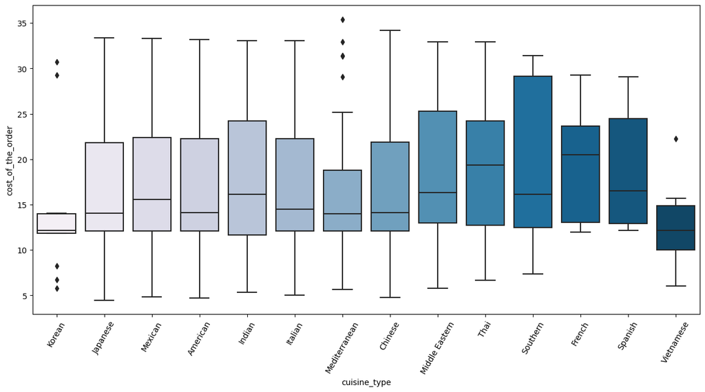

```python
# What is the relationship between cost_of_the_order and cuisine_type
plt.figure(figsize=(15,7))
sns.boxplot(x = "cuisine_type", y = "cost_of_the_order", data = df, palette = 'PuBu')
plt.xticks(rotation = 60)
plt.show()
```

Explain the code: Just like before, this code uses both the plt from matplotlib.pyplot and sns from seaborn to prepare and visualize the results as a boxplot.

Some additional components of this boxplot include assigning two specific columns as the x and y axis. The code is telling Python to take the data from the column 'cuisine_type' within the df data frame and plot that on the x-axis with the data from the column cost_of_the_order on the y-axis.

The pallette allows the analyst to choose color schemes for the plot by choosing from a pre-programmed list of options. This particular pallete is called 'PuBu' and gives the varying colors of blue.

#### Cuisine vs Food Preparation time

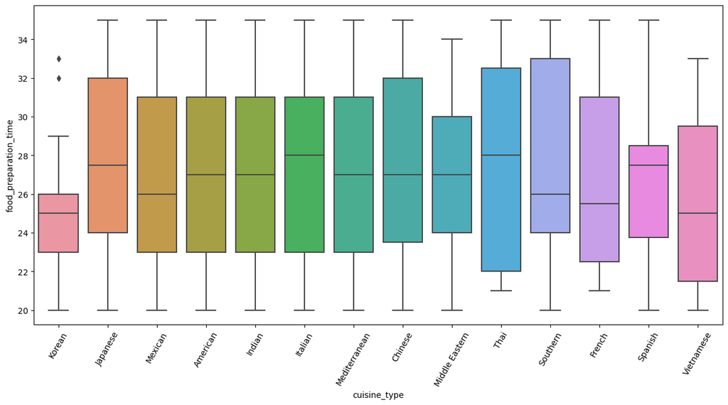

```python
# What is the relationship between food_preparation_time and cuisine_type
plt.figure(figsize=(15,7))
sns.boxplot(data=df, x = 'cuisine_type', y='food_preparation_time')  ## Complete the code to visualize the relationship between food preparation time and cuisine type using boxplot
plt.xticks(rotation = 60)
plt.show()
```

The box plot shows the distribution of the food preparation time vs. the individual type of cuisine. There are a few cuisines that have more skewness than others, mainly Korean, Southern, French, and Italian. This means that there are some orders where the preparation time is longer or shorter than the median for that cuisine.

#### Day of the Week vs Delivery time

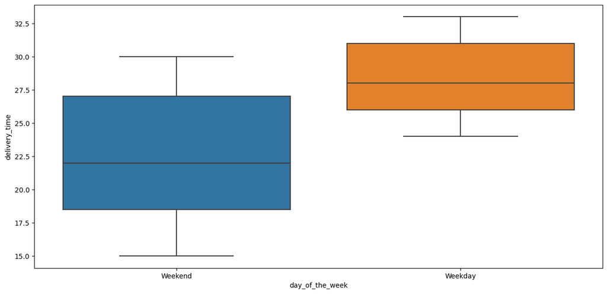

```python
# What is the relationship between day_of_the_week and delivery_time
plt.figure(figsize=(15,7))
sns.boxplot(data=df, x='day_of_the_week', y= 'delivery_time')  ## Complete the code to visualize the relationship between day of the week and delivery time using boxplot
plt.show()
```

#### Run the below code and write your observations on the revenue generated by the restaurants

```python
df.groupby(['restaurant_name'])['cost_of_the_order'].sum().sort_values(ascending = False).head(14)
```

```
restaurant_name
Shake Shack                      3579.53
The Meatball Shop                2145.21
Blue Ribbon Sushi                1903.95
Blue Ribbon Fried Chicken        1662.29
Parm                             1112.76
RedFarm Broadway                  965.13
RedFarm Hudson                    921.21
TAO                               834.50
Han Dynasty                       755.29
Blue Ribbon Sushi Bar & Grill     666.62
Rubirosa                          660.45
Sushi of Gari 46                  640.87
Nobu Next Door                    623.67
Five Guys Burgers and Fries       506.47
Name: cost_of_the_order, dtype: float64
```

#### Rating vs Delivery time

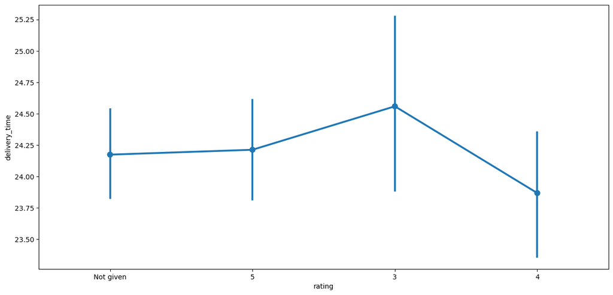

```python
# What is the relationship between rating and delivery time
plt.figure(figsize=(15, 7))
sns.pointplot(x = 'rating', y = 'delivery_time', data = df)
plt.show()
```

#### Rating vs Food preparation time

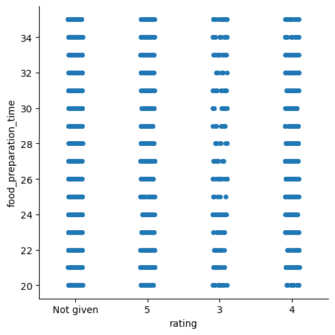

```python
# What is the relationship between rating and food preparation time
plt.figure(figsize=(15, 7))
sns.catplot(data=df, x = 'rating', y='food_preparation_time')
plt.show()
```

#### Rating vs Cost of the order

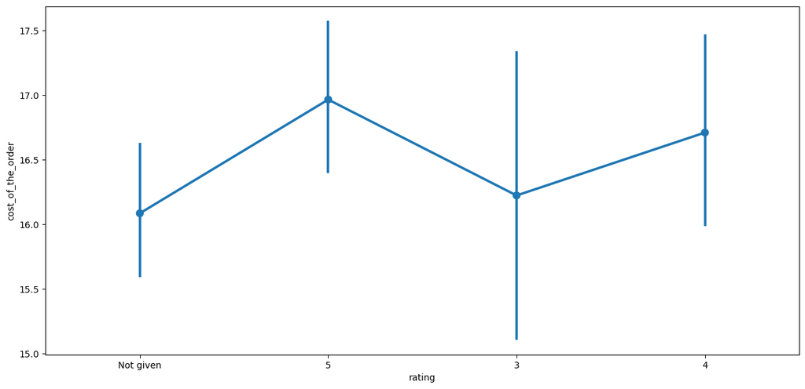

```python
# What is the relationship between rating and cost of the order
plt.figure(figsize=(15, 7))
sns.pointplot(data=df, x ='rating', y= 'cost_of_the_order')
## Complete the code to visualize the relationship between rating and cost of the order using pointplot
plt.show()
```

#### Correlation among variables

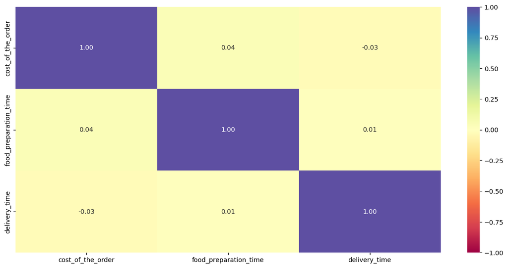

```python
# Create a heatmap
col_list = ['cost_of_the_order', 'food_preparation_time', 'delivery_time']
plt.figure(figsize=(15, 7))
sns.heatmap(df[col_list].corr(), annot=True, vmin=-1, vmax=1, fmt=".2f", cmap="Spectral")
plt.show()
```

The Heatmap shows the correlation between several variables. This correlation can be used to quickly identify if one variable has an impact on another. The scale represents the level of correlation with 0 being no correlation. As the values increase from 0, the correlation increases (positive correlation. Values less than 0 indicate a negative correlation. The results of this analysis indicate there is not a strong correlation between cost of the order, food preparation time, or delivery time.

### **Question 13:** The company wants to provide a promotional offer in the advertisement of the restaurants. The condition to get the offer is that the restaurants must have a rating count of more than 50 and the average rating should be greater than 4. Find the restaurants fulfilling the criteria to get the promotional offer

```python
# First step is to filter out the ratings that do not appy for the offer
df_rated = df[df['rating'] != 'Not given'].copy()

# Next step is to convert the data in this column to an integer
df_rated['rating'] = df_rated['rating'].astype('int')

# Final step is to create a new dataframe that has the count of the ratings and the restaurant names
df_rating_count = df_rated.groupby(['restaurant_name'])['rating'].count().sort_values(ascending = False).reset_index()
df_rating_count.head()
```

|  | restaurant_name | rating |
| --- | --- | --- |
| 0 | Shake Shack | 133 |
| 1 | The Meatball Shop | 84 |
| 2 | Blue Ribbon Sushi | 73 |
| 3 | Blue Ribbon Fried Chicken | 64 |
| 4 | RedFarm Broadway | 41 |

Explain the code:

1. Filter out the 'Not Given' ratings
- the code is telling Python to find the 'rating' column within the df dataframe. Then find the values 'Not given' within that dataframe. Make a copy of the dataframe and call it df_rated and copy over the results but exclude all the values 'Not given'.
1. Converting the values in the 'rating' column to integers
- the code is telling Python to find the 'rating' column within the new variable df_rated and cast them as type integer. Place these new results intoe the 'rating' column within the df_rated dataframe
1. Create a new dataframe df_rating_count
- the code is asking Python to take the columns 'restaurant_name' and 'rating' from the df_rated dataframe and sort the values in descending order. Group the results by restaurant name. Once the list is made, reset the index so the row numbers are reassigned for this dataframe (starting at 0)

```python
# Get the restaurant names that have rating count more than 50
df_rated = df[df['rating'] != 'Not given'].copy()

# Filter to get the data of restaurants that have rating count more than 50
df_rated['rating'] = df_rated['rating'].astype('int')

# Group the restaurant names with their ratings and find the mean rating of each restaurant
df_rating_count = df_rated.groupby(['restaurant_name'])['rating'].count().sort_values(ascending = False).reset_index()
df_rating_count.head()
```

|  | restaurant_name | rating |
| --- | --- | --- |
| 0 | Shake Shack | 133 |
| 1 | The Meatball Shop | 84 |
| 2 | Blue Ribbon Sushi | 73 |
| 3 | Blue Ribbon Fried Chicken | 64 |
| 4 | RedFarm Broadway | 41 |

```python
# Find the restaurants that have a rating of more than 50
rest_names = df_rating_count[df_rating_count['rating'] > 50]['restaurant_name']

# Filter the dataset to only show the restaurants with ratings higher than 50
df_mean_4 = df_rated[df_rated['restaurant_name'].isin(rest_names)].copy()

# Group the data by rating and restaurant name
df_mean_4.groupby('restaurant_name')['rating'].mean().sort_values(ascending=False).reset_index().dropna()
```

|  | restaurant_name | rating |
| --- | --- | --- |
| 0 | The Meatball Shop | 4.511905 |
| 1 | Blue Ribbon Fried Chicken | 4.328125 |
| 2 | Shake Shack | 4.278195 |
| 3 | Blue Ribbon Sushi | 4.219178 |

The results show that the top for restaurants with 50 or more ratings are

- The Meatball Shop
- Blue Ribbon Fried Chicken
- Shake Shack
- Blue Ribbon Sushi

The restaurant with the highest rating overall was The Meatball Shop

### **Question 14:** The company charges the restaurant 25% on the orders having cost greater than 20 dollars and 15% on the orders having cost greater than 5 dollars. Find the net revenue generated by the company across all orders

```python
# Create a function to calculate revenue
def compute_rev(x):
    if x > 20:
        return x*0.25
    elif x > 5:
        return x*0.15
    else:
        return x*0

df['Revenue'] = df['cost_of_the_order'].apply(compute_rev)
df.head()
```

[output not shown]

```python
# Find the total revenue and print the results
total_rev = df['Revenue'].sum()
print('The net revenue is around', round(total_rev, 2), 'dollars')
```

```
The net revenue is around 6166.3 dollars
```

### **Question 15:** The company wants to analyze the total time required to deliver the food. What percentage of orders take more than 60 minutes to get delivered from the time the order is placed? (The food has to be prepared and then delivered)

```python
df['total_time'] = df['food_preparation_time'] + df['delivery_time']


## Write the code below to find the percentage of orders that have more than 60 minutes of total delivery time (see Question 9 for reference)

# Get orders that have more than 60 minutes of total delivery time
df_greater_than_60 = df[df['total_time'] > 60]

# Calculate the number of total orders where the total delivery time is greater than 60
total_orders_greater_than_60 = df_greater_than_60.shape[0]

# Calculate the percentage of such orders in the dataset
percentage = (total_orders_greater_than_60 / df.shape[0]) * 100

print("Percentage of orders with more than 60 minutes of total delivery time:", round(percentage, 2), "%")
```

```
Percentage of orders with more than 60 minutes of total delivery time: 10.54 %
```

### **Question 16:** The company wants to analyze the delivery time of the orders on weekdays and weekends. How does the mean delivery time vary during weekdays and weekends?

```python
# Get the mean delivery time on weekdays and print it
print('The mean delivery time on weekdays is around',
      round(df[df['day_of_the_week'] == 'Weekday']['delivery_time'].mean()),
     'minutes')


## Write the code below to get the mean delivery time on weekends and print it
print('The mean delivery time on weekends is around',
      round(df[df['day_of_the_week'] == 'Weekend']['delivery_time'].mean()),
     'minutes')
```

```
The mean delivery time on weekdays is around 28 minutes
The mean delivery time on weekends is around 22 minutes
```

### Conclusion and Recommendations

### **Question 17:** What are your conclusions from the analysis? What recommendations would you like to share to help improve the business? (You can use cuisine type and feedback ratings to drive your business recommendations)

Increase Customer Feedback

Need to find a way to incentives the customers to provide feedback. About 39% of the experience is not being captured. Possible solution would be to offer a discount or coupon for future service if feedback is provided. Increasing the customer feedback is going to provide a significant increase in understanding the customer experience. The current data can be used as a benchmark for comparing future results after improvements or incentives are provided.

Smartphone App Enhancements

The app should be enhanced to allow for a breakdown of the variables that are currently being captured in “Food Preparation Time”. The app should be able to begin recording the time the order was placed by the customer so this can be used in conjunction with Food Preparation Time and Delivery Time. Currently, the time the order was placed, food preparation time, and restaurant confirmation time are all captured in the same metric called “Food Preparation Time.” Knowing when the order was placed on the app, when the order is being prepared at the restaurant, and when the order was complete will help provide better insight into the impact Food Preparation has on customer experiences.